# Supervised-ML

Shashwat Patel

03/02/2021

# Attaching the required packages

```r
library(tidyverse)
library(caTools)
library(gridExtra)
library(Metrics)
```

# Read the data

```r
data<-read_csv("score.csv")
```

```r
head(data)
```

```
## # A tibble: 6 x 2
##   Hours Scores
##   <dbl>  <dbl>
## 1   2.5     21
## 2   5.1     47
## 3   3.2     27
## 4   8.5     75
## 5   3.5     30
## 6   1.5     20
```

# Basic summary of the data

```r
summary(data)
```

```
##      Hours           Scores
##  Min.   :1.100   Min.   :17.00
##  1st Qu.:2.700   1st Qu.:30.00
##  Median :4.800   Median :47.00
##  Mean   :5.012   Mean   :51.48
##  3rd Qu.:7.400   3rd Qu.:75.00
##  Max.   :9.200   Max.   :95.00
```

**In the below plot, it can be clearly seen that Scores and Hours have some what a linear relationship between them, so linear regrression makes good fit for the data.**

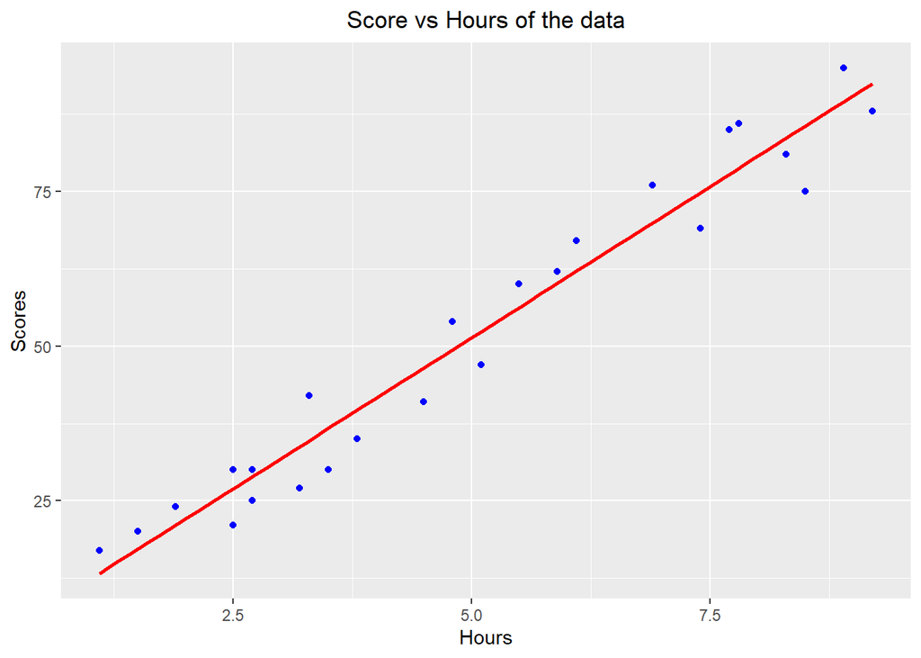

```r
data%>% ggplot()+ geom_point(aes(x=Hours,y=Scores),colour="blue")+
          geom_smooth(aes(x=Hours,y=Scores),method = "lm",formula = y~x,se=FALSE,colour="red")+
          ggtitle("Score vs Hours of the data")+theme(plot.title=element_text(hjust=0.5))
```

**There is no outlier as well, clearly seen from the boxplots**

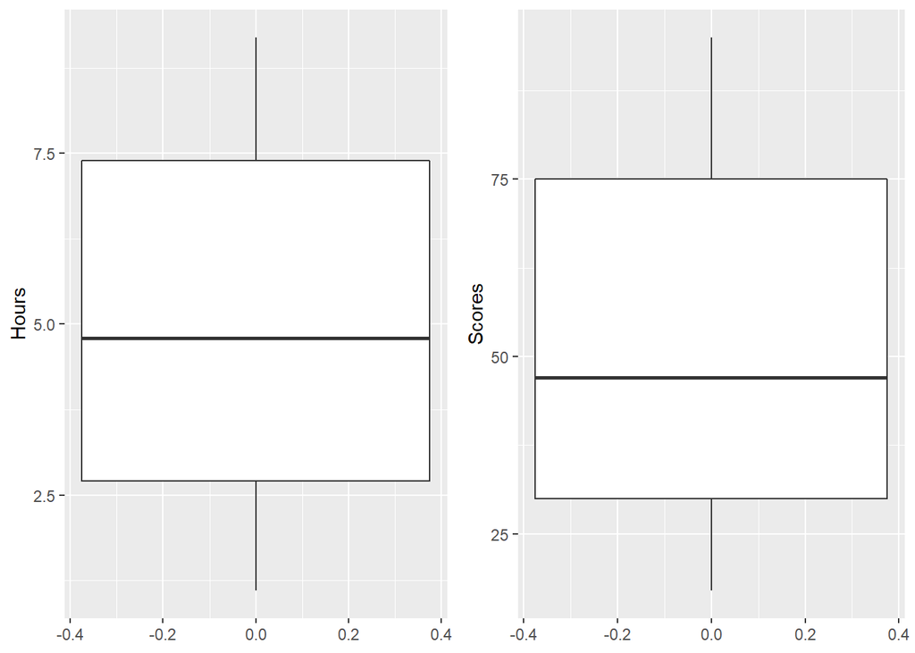

```r
p1<-data%>% ggplot()+geom_boxplot(aes(y=Hours))

p2<-data%>% ggplot()+geom_boxplot(aes(y=Scores))
grid.arrange(p1,p2,nrow=1)
```

### **Splitting the data in training set and test set.**

```r
set.seed(2)
split<-sample.split(data$Hours,SplitRatio = 0.8)
training_data<-subset(data,split==TRUE)
test_data<-subset(data,split==FALSE)
```

### **Fitting the linear model**

- The results reject the null hypothesis.
- The p-value of Hours variable is very low, so Hour variable is highly significant.
- Its t value is also high as compared with standard error.
- Adjusted R-squared is 0.9428, showing significant relationship between Hours variable and the dependent Score data.

```r
regressor<-lm(formula=Scores~Hours,data = training_data)
summary(regressor)
```

```
##
## Call:
## lm(formula = Scores ~ Hours, data = training_data)
##
## Residuals:
##     Min      1Q  Median      3Q     Max
## -10.022  -5.385   1.324   4.649   7.702
##
## Coefficients:
##             Estimate Std. Error t value Pr(>|t|)
## (Intercept)    3.370      3.129   1.077    0.296
## Hours          9.606      0.542  17.725 7.66e-13 ***
## ---
## Signif. codes:  0 '***' 0.001 '**' 0.01 '*' 0.05 '.' 0.1 ' ' 1
##
## Residual standard error: 5.795 on 18 degrees of freedom
## Multiple R-squared:  0.9458, Adjusted R-squared:  0.9428
## F-statistic: 314.2 on 1 and 18 DF,  p-value: 7.663e-13
```

- Corrleation btween Hour and Score also suggest a strong relationship.

```r
cor(data$Hours,data$Scores)
```

```
## [1] 0.9761907
```

### **Prediction scores for test set**

```r
score_prediction<-predict(regressor,newdata=test_data)
act_pred_data<-data.frame(Hours=test_data$Hours,Actual_score=test_data$Scores,Predicted_score=score_prediction)
act_pred_data
```

```
##   Hours Actual_score Predicted_score
## 1   3.5           30        36.99123
## 2   1.5           20        17.77895
## 3   8.9           95        88.86437
## 4   2.5           30        27.38509
## 5   3.8           35        39.87307
```

**In the 1st plot, the model is fitted on training set and we can see the regression line as well as training data, In the 2nd plot the model is fitted on test set and regression line is also present.**

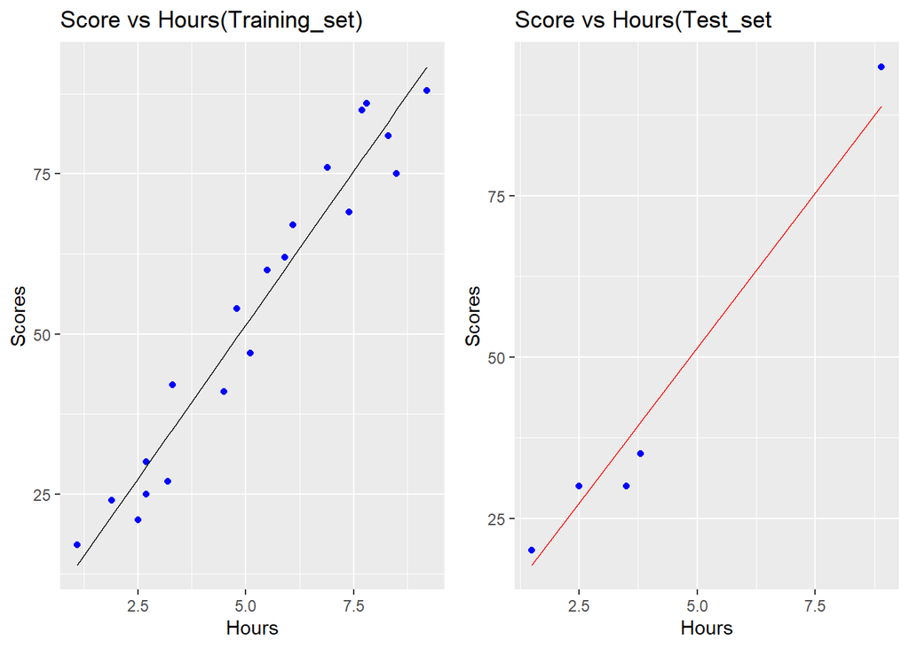

```r
pl1<-ggplot()+geom_point(aes(x=training_data$Hours,y=training_data$Scores),colour="blue")+
     geom_line(aes(x=training_data$Hours,y=predict(regressor,training_data)))+ggtitle("Score vs Hours(Training_set) ")+xlab("Hours") +
  ylab("Scores")
pl2<-ggplot()+geom_point(aes(x=test_data$Hours,y=test_data$Scores),colour="blue")+
     geom_line(aes(x=test_data$Hours,y=score_prediction),colour="red")+ggtitle("Score vs Hours(Test_set") +
  xlab("Hours") +
  ylab("Scores")
grid.arrange(pl1,pl2,nrow=1)
```

### **The predicted score for a student who studied for 9.5 hours**

```r
new_data<-data.frame(Hours=9.5,Score=NA)
Predicted_score<-predict(regressor,new_data)
Predicted_score
```

```
##        1
## 94.62806
```

# Model Accuracy

**It shows the mean absolute error is 4.567176, and root mean sqaured error is 4.9404. These are prettly low, which suggests that our model is pretty accurate.**

```r
mean_absolute_error<-mae(act_pred_data$Actual_score,act_pred_data$Predicted_score)
root_mean_squared_error<-rmse(act_pred_data$Actual_score,act_pred_data$Predicted_score)
root_mean_squared_error
```

```
## [1] 4.940461
```

```r
mean_absolute_error
```

```
## [1] 4.567176
```